# Quantum Computing - ANPA 2020

# Introduction

Quantum computers have many advantages over classical computers. One of the advantages is its superior speed searching in the databases. This ability can be demonstrated by using Grover's algorithm. For example, finding the needle in a haystack or searching the address of a people in a phone diary is an unstructured database search, and it takes a long time to find the correct solution. Grover's algorithm speeds up unstructured search probability quadratically by using the amplitude-amplification trick.

[figure not shown]

Let's consider a large list of N items. Among these items, there is one item with a unique property that we wish to locate; we will call this one the winner (w). In a classical way, search for the winner item (w) needs to check 1 to N boxes. So, on average it needs to check N/2 boxes or steps.

But, using Grover's Algorithm, search steps can be reduced to $\sqrt(N)$. So, it will be a substantial time-saver to find the marked items along with the list. Another advantage of this algorithm does not use the list's internal structure.

# Example

To understand it, let's begin with 2 qubits list. Its total possible states will be 4 ($2^2 =4$). i.e, 00, 01, 10, 11,. In counting it will be $|0>$ to upto $|3>$.

Grover’s algorithm solves oracles that add a negative phase to the solution states. i.e. for any states |x⟩ in the computational basis:

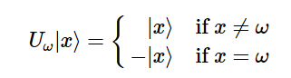

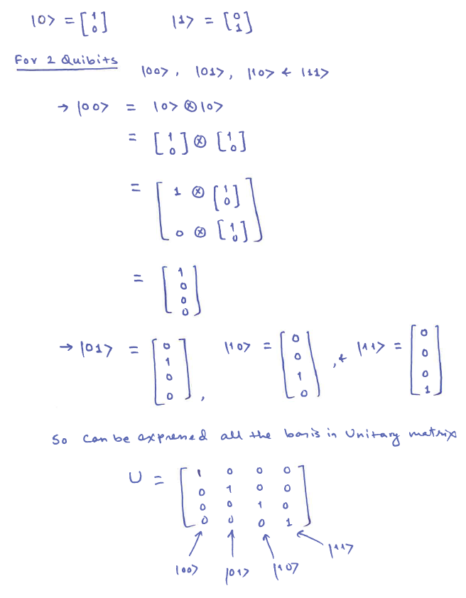

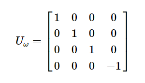

and the oracle's matrix will be a diagonal matrix of the form:

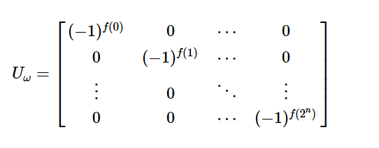

# Amplitude amplification

Before looking at the list of items, we have no idea where the marked item is. Therefore, any guess of its location is as good as any other, which can be expressed in terms of a uniform superposition:

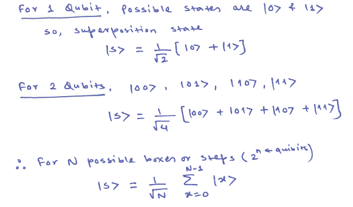

When we measure it, the superposition would collapse with any of the basis states having the same probability of $1/N$ or $1/2^n$. So, Our chances of guessing the right value w is therefore 1 in $2^n$. Amplitude amplification trick stretches out the amplitude of the marked item, which shrinks the other sites' amplitude so that measuring the final state will return the right item with near-certainty.

This algorithm has a nice geometrical interpretation in terms of two reflections, which generate rotation in a two-dimensional plane. The only two special states we need to consider are the winner $|w⟩$ and the uniform superposition $|s⟩$.

They are not quite perpendicular because $|w⟩$ occurs in the superposition with amplitude $N^{−1/2}$ as well. We can, however, introduce an additional state |s′⟩ that is in the span of these two vectors, which is perpendicular to $|w⟩$ and is obtained from |s⟩ by removing |w⟩ and rescaling.

# Step 1:

Supreposition state $|s>$ can be represented in 2D

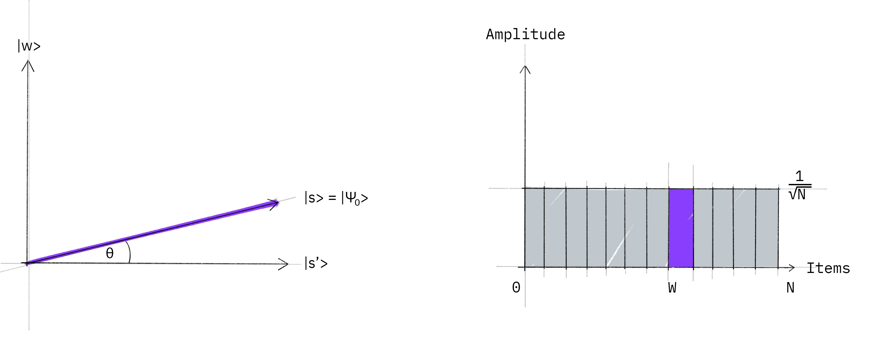

# Step 2:

Apply oracle reflection $U_f$

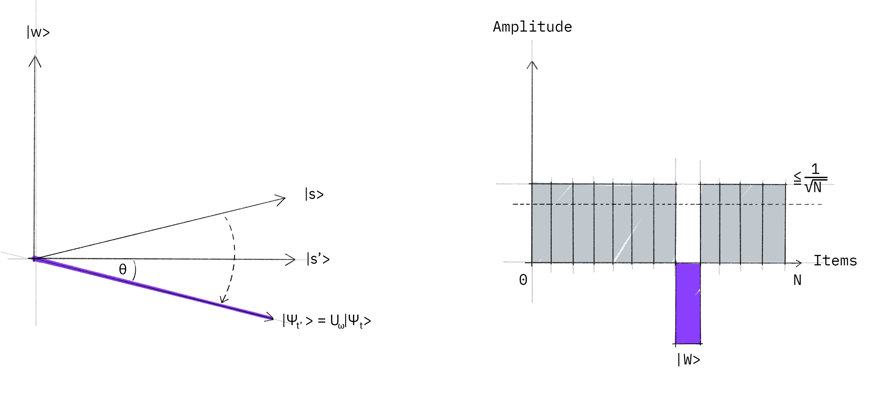

# Step 3:

We now apply an additional reflection ($U_s$) = $2|s><s|-I$

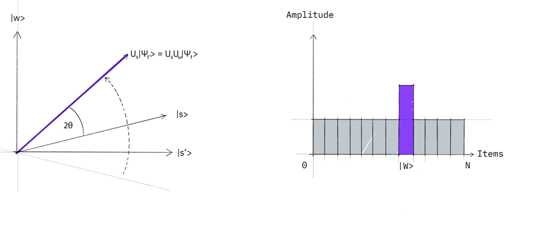

Two reflections always correspond to a rotation. The transformation $U_sU_f$ rotates the initial state $|s⟩$ closer towards the winner $|w⟩$. The action of the reflection $U_s$ in the amplitude bar diagram can be understood as a reflection about the average amplitude. Since the average amplitude has been lowered by the first reflection, this transformation boosts the negative amplitude of $|w⟩$ to roughly three times its original value, while it decreases the other amplitudes. We then go to step 2 to repeat the application. This procedure will be repeated several times to zero in on the winner.

After t steps we will be in the state:

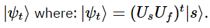

In terms of angle, in $U_f$ rotation, $|s>$ does reflection by $\theta$ degree alnot $|s'>$ and with with $U_s$ application, $|s>$ does reflection along the original $|s>$ states. So, superposition verctor $|s>$ made ($\theta$ +2 $\theta)$ roataion.

So for t complete application of $U_sU_f$: $|s>$ will rotate by (2t + 1)$\theta$ angle.

the amplitude of $|w>$ grows linearly with the number of application neartly $tN^{-1/2}$. Hence roghthly $\sqrt{N}$ rotation is sufficent.

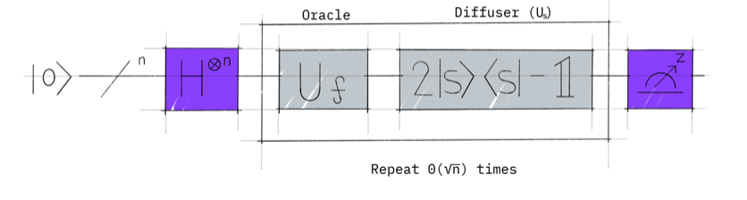

# Example: 2 Qubits

N =4, one rotation is enought to rotate the initial state $|s>$ to the winner state $|w>$.

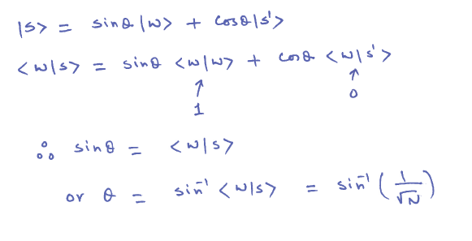

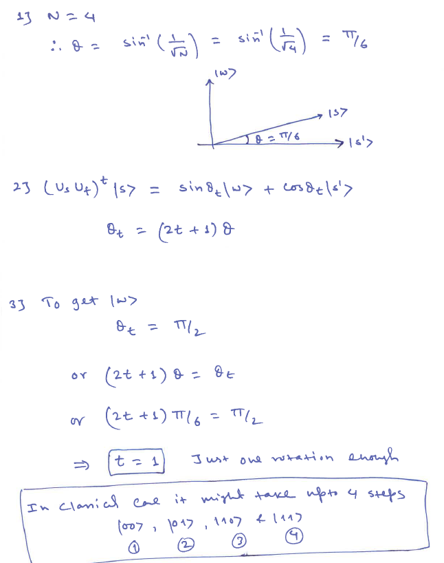